# Neginhib Diffusion Models

Ann E. Nordmeyer

Analysis for Neginhib (Ann Nordmeyer, Erica Yoon, Mike Frank). The study included three games designed to test the relationship between inhibitory control, implicature processing, and negation processing. All games had a similar structure: participants saw two pictures and heard a word, and had to select the picture that goes with the word as quickly as possible. Each game had two trial types, labeled *control* and *target* in these analyses. The three games were:

**Inhibition Game** : Participants saw several identical trials in a row (e.g. the word “apple” with pictures of an apple and a cookie) and then saw a trial with the same pictures but a different word (e.g. “cookie” with pictures of an apple and a cookie). The repeated trials in each run are the *control* trials and the final trial in each run was the *target* trial, designed to measure inhibitory control.

**Implicature Game**: On *control* / unambiguous trials, participants saw two single pictures (e.g. a picture of an apple and a picture of a cookie) and heard a word referring to one of the pictures (e.g. “apple”). On *target* / implicatures trials, participants saw a picture with a single item and a picture with the same item paired with another item (e.g. a picture of an apple, and a picture of an apple and a cookie) and heard e.g. “apple”. The “correct” response on these trials is the response generated by the ad-hoc implicature, e.g. that “apple” must refer to the single apple because otherwise the speaker would have said “cookie”.

**Negation Game**: On *control* / positive trials, participants saw two pictures and heard a word referring to one of the pictures (e.g. a picture of an apple and a picture of a cookie, with the word “apple”). On *target* / negative trials, participants saw two pictures and heard a word negating one of the pictures (e.g. a picture of an apple and a picture of a cookie, with the words “no apple”).

Kids played these games at Bing on an iPad (only 4-year-olds) or at the CDM on a computer (4, 5, and 6-year-olds), with 60 trials per game in both the iPad and the computer version. Adults completed the task on MTurk, with 120 trials per game. The adult version of the task can be viewed here: https://langcog.stanford.edu/expts/EJY/neginhib/v1/turk/neginhib_mturk.html

# Setting up

Load required Libraries

```r
rm(list=ls())
library(ggplot2)
library(dplyr)
library(tidyr)
library(magrittr)
#library(directlabels)
library(RWiener)
library(knitr)
library(bootstrap)
library(gridExtra)
library(effsize)
library(lme4)
```

Some useful functions:

```r
# number of unique subs
n.unique <- function (x) {
  length(unique(x))
}

# for bootstrapping 95% confidence intervals
theta <- function(x,xdata) {mean(xdata[x])}
ci.low <- function(x) {
  quantile(bootstrap(1:length(x),1000,theta,x)$thetastar,.025)}
ci.high <- function(x) {
  quantile(bootstrap(1:length(x),1000,theta,x)$thetastar,.975)}
```

Load in data

RT trimming:

- Planned analysis: +/- 3SDs in log space
- Post-hoc: also trim decisions < 200 ms from word onsent, > 15s (!) after offset, do this before planned outlier exclusion, doesn’t change the results but makes things more reasonable.

```r
d.turk <- read.csv("../long_data/long_data_mturk.csv")
n.turk.initial <- n.unique(d.turk$subid)

d.turk <- d.turk %>%
  # remove anyone who played fewer than 300 trials (means they did not complete at least half of the third game) or over 408 trials (means they completed the task twice, because 408 is max number of trials -- this only happened for one participant and I'm not sure how they were able to do this, so I'm rejecting them)
  mutate(subid = factor(subid)) %>%
  group_by(subid) %>%
  mutate(ntrials = n()) %>%
  filter(ntrials > 300 & ntrials < 408) %>%
  ungroup() %>%
  # create resp and rt vars
  mutate(resp = factor(response, levels=c("Y","N"), labels=c("upper","lower")),
         q = rt/1000) %>%
  # remove outlier RTs
  filter(rt > 200,
         rt < 15000) %>% # filtering the mysterious neg rt...
  filter(log(rt) < mean(log(rt) + 3 * sd(log(rt))),
         log(rt) > mean(log(rt) - 3 * sd(log(rt)))) %>%
  # clean up
  select(subid, game, trial.num, trial.type, q, resp) %>%
  mutate(location = "turk",
         modality = "computer",
         agegroup = "adults") %>%
  ungroup()
n.turk.final <- n.unique(d.turk$subid)

d.bing <- read.csv("../long_data/long_data_bing.csv") %>%
  filter(agegroup == 4)
n.bing.initial <- n.unique(d.bing$subid)

d.bing <- d.bing %>%
  # remove any child who played fewer than 150 trials (means they didn't complete at least half of the final game)
  group_by(subid) %>%
  mutate(ntrials = n()) %>%
  filter(ntrials > 150) %>%
  ungroup() %>%
  # create resp and rt vars
  mutate(resp = factor(response, levels=c("Y","N"), labels=c("upper","lower")),
         q = rt/1000) %>%
  # remove outlier RTs
  filter(rt > 200,
         rt < 15000) %>% # filtering the mysterious neg rt...
  filter(log(rt) < mean(log(rt) + 3 * sd(log(rt))),
         log(rt) > mean(log(rt) - 3 * sd(log(rt))))
m_age_4ipad <- mean(d.bing$age)
min_age_4ipad <- min(d.bing$age)
max_age_4ipad <- max(d.bing$age)

d.bing <- d.bing %>%
  # clean up
  select(subid, agegroup, game, trial.num, trial.type, q, resp) %>%
  mutate(location = "preschool",
         modality = "iPad",
         agegroup = factor(agegroup)) %>%
  ungroup()
n.bing.final <- n.unique(d.bing$subid)

d.cdm.raw <- read.csv("../long_data/long_data_cdm.csv") %>%
  filter(agegroup == 4 | agegroup == 5 | agegroup == 6)
n.cdm.initial <- n.unique(d.cdm.raw$subid)

d.cdm <- d.cdm.raw %>%
  # remove any child who played fewer than 150 trials (means they didn't complete at least half of the final game)
  group_by(subid) %>%
  mutate(ntrials = n()) %>%
  filter(ntrials > 150) %>%
  ungroup() %>%
  group_by(agegroup) %>% #Note: doing rt trimming within age group for this sample
  # create resp and rt vars
  mutate(resp = factor(response, levels=c("Y","N"), labels=c("upper","lower")),
         q = rt/1000) %>%
  # remove outlier RTs
  filter(rt > 200,
         rt < 15000) %>% # filtering the mysterious neg rt...
  filter(log(rt) < mean(log(rt) + 3 * sd(log(rt))),
         log(rt) > mean(log(rt) - 3 * sd(log(rt)))) %>%
  ungroup()
m_age_comp <- aggregate(age ~ agegroup, d.cdm, mean)
min_age_comp <- aggregate(age ~ agegroup, d.cdm, min)
max_age_comp <- aggregate(age ~ agegroup, d.cdm, max)

d.cdm <- d.cdm %>%
  # clean up
  select(subid, age, agegroup, game, trial.num, trial.type, q, resp) %>%
  mutate(location = "museum",
         modality = "computer",
         agegroup = factor(agegroup)) %>%
  ungroup()
n.cdm.final <- n.unique(d.cdm$subid)
ns.cdm <- aggregate(subid ~ agegroup, d.cdm, n.unique)

d <- bind_rows(d.turk, d.bing, d.cdm)
d$subid <- factor(d$subid)
d$location <- factor(d$location)
d$modality <- factor(d$modality)
d$agegroup <- factor(d$agegroup, levels = c("adults", "4", "5", "6"))
d$agegroup_modality <- factor(paste(d$agegroup, d$modality, sep = "_"), levels = c("4_iPad", "4_computer", "5_computer", "6_computer", "adults_computer"))
d$trial.type <- factor(d$trial.type, levels = c("control", "inhib", "unambiguous", "implicature", "positive", "negative"))

d$correct <- as.numeric(as.character(factor(d$resp, levels=c("upper","lower"), labels=c("1","0"))))==1
d$trial.crit <- factor(d$trial.type %in% c("inhib","implicature","negative"),
                       levels = c(FALSE, TRUE),
                       labels = c("control","target"))
d$game <- factor(d$game, levels=c("inhibition","implicature","negation"))

d <- d %>%
  mutate(agegroup2 = ifelse(agegroup == "adults", "adults", "kids"))
```

We excluded 2 adult participants, 1 child iPad participants (Bing), and 24 child computer participants (CDM) for failing to complete at least half of the trials in each game. This left a final sample of 48 adult participants, 19 child iPad participants (Bing), and 66 child computer participants (CDM).

The iPad/bing sample ranged in age from 4.04 to 4.99, with a mean age of 4.53. The computer/cdm sample included 22 4-year-olds (age range 4.01-4.99, mean age = 4.6), 19 5-year-olds (age range 5.03-5.95, mean age = 5.49), and 25 6-year-olds (age range 6-6.99, mean age = 6.46).

# Initial analysis

## Proportion Correct

Proportion correct:

```
## ymax not defined: adjusting position using y instead
## ymax not defined: adjusting position using y instead
## ymax not defined: adjusting position using y instead
```

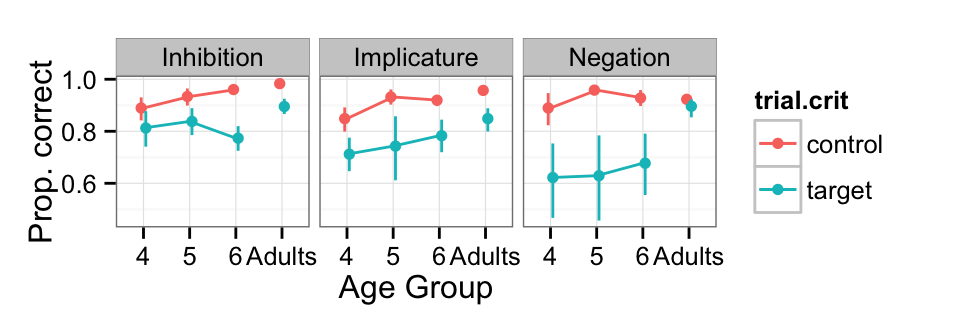

```r
ms <- d %>%
  filter(modality == "computer") %>%
  group_by(game, trial.crit, subid, agegroup) %>%
  summarise(m = mean(correct)) %>%
  group_by(game, trial.crit, agegroup) %>%
  summarise(cih = ci.high(m),
            cil = ci.low(m),
            m = mean(m))
ms$agegroup <- factor(ms$agegroup, levels = c("4", "5", "6", "adults"), c("4", "5", "6", "Adults"))
ms$game <- factor(ms$game, labels = c("Inhibition", "Implicature", "Negation"))

ms$kid <- ms$agegroup != "Adults"
qplot(data=ms, x=agegroup, y=m, color=trial.crit,
      geom="point", position=position_dodge(.2)) +
  geom_errorbar(aes(ymin=cil, ymax=cih),
                position=position_dodge(.2), width=0) +
  geom_line(aes(group = interaction(kid,trial.crit), col = trial.crit)) +
  facet_grid( ~ game) +
  ylab("Prop. correct") + xlab("Age Group") +
  scale_fill_hue(name="Trial Type") +
  theme_bw()
```

```r
##Inhibition:
correct.inhib <- glmer(correct ~ trial.crit * agegroup2 + (trial.crit | subid),
                             data = filter(d, game == "inhibition",
                                           modality == "computer"),
                             family = "binomial")
summary(correct.inhib)
```

```
## Generalized linear mixed model fit by maximum likelihood (Laplace
##   Approximation) [glmerMod]
##  Family: binomial  ( logit )
## Formula: correct ~ trial.crit * agegroup2 + (trial.crit | subid)
##    Data: filter(d, game == "inhibition", modality == "computer")
##
##      AIC      BIC   logLik deviance df.resid
##   4434.4   4486.4  -2210.2   4420.4    12444
##
## Scaled residuals:
##      Min       1Q   Median       3Q      Max
## -11.9381   0.0909   0.1500   0.2287   1.0218
##
## Random effects:
##  Groups Name             Variance Std.Dev. Corr
##  subid  (Intercept)      1.0360   1.0178
##         trial.crittarget 0.6472   0.8045   -0.67
## Number of obs: 12451, groups:  subid, 114
##
## Fixed effects:
##                                Estimate Std. Error z value Pr(>|z|)
## (Intercept)                      4.4896     0.1901  23.615  < 2e-16 ***
## trial.crittarget                -2.0956     0.2019 -10.381  < 2e-16 ***
## agegroup2kids                   -1.4504     0.2363  -6.137  8.4e-10 ***
## trial.crittarget:agegroup2kids   0.6292     0.2472   2.545   0.0109 *
## ---
## Signif. codes:  0 '***' 0.001 '**' 0.01 '*' 0.05 '.' 0.1 ' ' 1
##
## Correlation of Fixed Effects:
##             (Intr) trl.cr aggrp2
## trl.crttrgt -0.670
## agegrop2kds -0.771  0.505
## trl.crttr:2  0.512 -0.754 -0.646
```

```r
correct.inhib.kids <- glmer(correct ~ trial.crit * age + (trial.crit | subid),
                             data = filter(d, game == "inhibition",
                                           modality == "computer",
                                           agegroup != "adults"),
                             family = "binomial")
summary(correct.inhib.kids)
```

```
## Generalized linear mixed model fit by maximum likelihood (Laplace
##   Approximation) [glmerMod]
##  Family: binomial  ( logit )
## Formula: correct ~ trial.crit * age + (trial.crit | subid)
##    Data:
## filter(d, game == "inhibition", modality == "computer", agegroup !=
##     "adults")
##
##      AIC      BIC   logLik deviance df.resid
##   2643.6   2689.3  -1314.8   2629.6     5006
##
## Scaled residuals:
##     Min      1Q  Median      3Q     Max
## -8.1769  0.1375  0.2078  0.3325  0.9141
##
## Random effects:
##  Groups Name             Variance Std.Dev. Corr
##  subid  (Intercept)      1.0496   1.0245
##         trial.crittarget 0.5492   0.7411   -0.88
## Number of obs: 5013, groups:  subid, 66
##
## Fixed effects:
##                      Estimate Std. Error z value Pr(>|z|)
## (Intercept)           0.03833    0.98410   0.039  0.96893
## trial.crittarget      2.31104    1.00206   2.306  0.02109 *
## age                   0.54941    0.17746   3.096  0.00196 **
## trial.crittarget:age -0.69968    0.17917  -3.905 9.42e-05 ***
## ---
## Signif. codes:  0 '***' 0.001 '**' 0.01 '*' 0.05 '.' 0.1 ' ' 1
##
## Correlation of Fixed Effects:
##             (Intr) trl.cr age
## trl.crttrgt -0.705
## age         -0.988  0.699
## trl.crttrg:  0.706 -0.987 -0.718
```

```r
##Implicature:
correct.imp <- glmer(correct ~ trial.crit * agegroup2 + (trial.crit | subid),
                             data = filter(d, game == "implicature",
                                           modality == "computer"),
                             family = "binomial")
summary(correct.imp)
```

```
## Generalized linear mixed model fit by maximum likelihood (Laplace
##   Approximation) [glmerMod]
##  Family: binomial  ( logit )
## Formula: correct ~ trial.crit * agegroup2 + (trial.crit | subid)
##    Data: filter(d, game == "implicature", modality == "computer")
##
##      AIC      BIC   logLik deviance df.resid
##   6222.6   6272.8  -3104.3   6208.6     9604
##
## Scaled residuals:
##     Min      1Q  Median      3Q     Max
## -6.7896  0.1657  0.2458  0.3352  2.5830
##
## Random effects:
##  Groups Name             Variance Std.Dev. Corr
##  subid  (Intercept)      0.5992   0.7741
##         trial.crittarget 1.3495   1.1617   -0.23
## Number of obs: 9611, groups:  subid, 114
##
## Fixed effects:
##                                Estimate Std. Error z value Pr(>|z|)
## (Intercept)                      3.3693     0.1556  21.657  < 2e-16 ***
## trial.crittarget                -1.1448     0.2126  -5.384 7.27e-08 ***
## agegroup2kids                   -0.9493     0.1957  -4.852 1.22e-06 ***
## trial.crittarget:agegroup2kids   0.1220     0.2725   0.448    0.654
## ---
## Signif. codes:  0 '***' 0.001 '**' 0.01 '*' 0.05 '.' 0.1 ' ' 1
##
## Correlation of Fixed Effects:
##             (Intr) trl.cr aggrp2
## trl.crttrgt -0.483
## agegrop2kds -0.748  0.349
## trl.crttr:2  0.342 -0.748 -0.451
```

```r
correct.imp.kids <- glmer(correct ~ trial.crit * age + (trial.crit | subid),
                             data = filter(d, game == "implicature",
                                           modality == "computer",
                                           agegroup != "adults"),
                             family = "binomial")
summary(correct.imp.kids)
```

```
## Generalized linear mixed model fit by maximum likelihood (Laplace
##   Approximation) [glmerMod]
##  Family: binomial  ( logit )
## Formula: correct ~ trial.crit * age + (trial.crit | subid)
##    Data:
## filter(d, game == "implicature", modality == "computer", agegroup !=
##     "adults")
##
##      AIC      BIC   logLik deviance df.resid
##   3199.0   3242.9  -1592.5   3185.0     3916
##
## Scaled residuals:
##     Min      1Q  Median      3Q     Max
## -4.5777  0.2073  0.2901  0.4173  2.6411
##
## Random effects:
##  Groups Name             Variance Std.Dev. Corr
##  subid  (Intercept)      0.5275   0.7263
##         trial.crittarget 1.5337   1.2384   -0.34
## Number of obs: 3923, groups:  subid, 66
##
## Fixed effects:
##                      Estimate Std. Error z value Pr(>|z|)
## (Intercept)            0.5969     0.7973   0.749   0.4541
## trial.crittarget      -0.3683     1.2268  -0.300   0.7640
## age                    0.3287     0.1430   2.299   0.0215 *
## trial.crittarget:age  -0.1188     0.2193  -0.542   0.5881
## ---
## Signif. codes:  0 '***' 0.001 '**' 0.01 '*' 0.05 '.' 0.1 ' ' 1
##
## Correlation of Fixed Effects:
##             (Intr) trl.cr age
## trl.crttrgt -0.493
## age         -0.987  0.487
## trl.crttrg:  0.488 -0.988 -0.496
```

```r
##Negation:
correct.neg <- glmer(correct ~ trial.crit * agegroup2 + (trial.crit | subid),
                             data = filter(d, game == "negation",
                                           modality == "computer"),
                             family = "binomial")
summary(correct.neg)
```

```
## Generalized linear mixed model fit by maximum likelihood (Laplace
##   Approximation) [glmerMod]
##  Family: binomial  ( logit )
## Formula: correct ~ trial.crit * agegroup2 + (trial.crit | subid)
##    Data: filter(d, game == "negation", modality == "computer")
##
##      AIC      BIC   logLik deviance df.resid
##   5910.2   5960.4  -2948.1   5896.2     9583
##
## Scaled residuals:
##     Min      1Q  Median      3Q     Max
## -6.4499  0.1781  0.2349  0.3566  3.5357
##
## Random effects:
##  Groups Name             Variance Std.Dev. Corr
##  subid  (Intercept)      0.8716   0.9336
##         trial.crittarget 3.1046   1.7620   -0.36
## Number of obs: 9590, groups:  subid, 114
##
## Fixed effects:
##                                Estimate Std. Error z value Pr(>|z|)
## (Intercept)                      2.7459     0.1580  17.379  < 2e-16 ***
## trial.crittarget                -0.1794     0.2791  -0.643    0.520
## agegroup2kids                    0.1904     0.2205   0.863    0.388
## trial.crittarget:agegroup2kids  -1.9843     0.3747  -5.296 1.19e-07 ***
## ---
## Signif. codes:  0 '***' 0.001 '**' 0.01 '*' 0.05 '.' 0.1 ' ' 1
##
## Correlation of Fixed Effects:
##             (Intr) trl.cr aggrp2
## trl.crttrgt -0.433
## agegrop2kds -0.684  0.291
## trl.crttr:2  0.303 -0.733 -0.465
```

```r
correct.neg.kids <- glmer(correct ~ trial.crit * age + (trial.crit | subid),
                             data = filter(d, game == "negation",
                                           modality == "computer",
                                           agegroup != "adults"),
                             family = "binomial")
summary(correct.neg.kids)
```

```
## Generalized linear mixed model fit by maximum likelihood (Laplace
##   Approximation) [glmerMod]
##  Family: binomial  ( logit )
## Formula: correct ~ trial.crit * age + (trial.crit | subid)
##    Data:
## filter(d, game == "negation", modality == "computer", agegroup !=
##     "adults")
##
##      AIC      BIC   logLik deviance df.resid
##   2674.6   2718.5  -1330.3   2660.6     3912
##
## Scaled residuals:
##     Min      1Q  Median      3Q     Max
## -5.1552  0.1405  0.2032  0.4033  3.9945
##
## Random effects:
##  Groups Name             Variance Std.Dev. Corr
##  subid  (Intercept)      1.385    1.177
##         trial.crittarget 5.903    2.430    -0.46
## Number of obs: 3919, groups:  subid, 66
##
## Fixed effects:
##                      Estimate Std. Error z value Pr(>|z|)
## (Intercept)           2.67857    1.23032   2.177   0.0295 *
## trial.crittarget     -2.46718    2.22568  -1.109   0.2676
## age                   0.07097    0.21719   0.327   0.7438
## trial.crittarget:age  0.02961    0.39504   0.075   0.9402
## ---
## Signif. codes:  0 '***' 0.001 '**' 0.01 '*' 0.05 '.' 0.1 ' ' 1
##
## Correlation of Fixed Effects:
##             (Intr) trl.cr age
## trl.crttrgt -0.535
## age         -0.987  0.528
## trl.crttrg:  0.525 -0.988 -0.532
```

So kids are much less accurate than adults on target trials, especially in the implicature and negation games. It looks like 4-year-olds are a little more accurate on the computer, and children show some improvement on the implicatures game across development but maybe not so much improvement across development on the negation game?

## Reaction time

What about reaction time? Here we just look at RTs on correct trials (outlier RTs were trimmed earlier when the data was loaded).

```
## ymax not defined: adjusting position using y instead
## ymax not defined: adjusting position using y instead
## ymax not defined: adjusting position using y instead
```

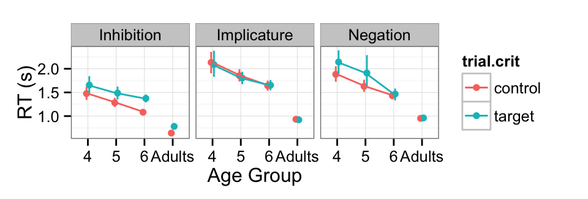

```r
#Plot data
ms <- d %>%
  filter(correct == TRUE, modality == "computer") %>%
  group_by(game, trial.crit, subid, agegroup) %>%
  summarise(m = mean(q)) %>%
  group_by(game, trial.crit, agegroup) %>%
  summarise(cih = ci.high(m),
            cil = ci.low(m),
            m = mean(m))
ms$agegroup <- factor(ms$agegroup, levels = c("4", "5", "6", "adults"), labels = c("4", "5", "6", "Adults"))
ms$game <- factor(ms$game, labels = c("Inhibition", "Implicature", "Negation"))
#kable(summary(xflips.exp1)$coefficients, digits = 3)

ms$kid <- ms$agegroup != "Adults"
qplot(data=ms, x=agegroup, y=m, color=trial.crit,
      geom="point", position=position_dodge(.2)) +
  geom_errorbar(aes(ymin=cil, ymax=cih),
                position=position_dodge(.2), width=0) +
  geom_line(aes(group = interaction(kid,trial.crit), col = trial.crit)) +
  facet_grid( ~ game) +
  ylab("RT (s)") + xlab("Age Group") +
  scale_fill_hue(name="Trial Type") +
  theme_bw()
```

```r
##Inhibition:
q.inhib <- lmer(q ~ trial.crit * agegroup2 + (trial.crit | subid),
                             data = filter(d, game == "inhibition",
                                           modality == "computer",
                                           correct == TRUE))
summary(q.inhib)
```

```
## Linear mixed model fit by REML ['lmerMod']
## Formula: q ~ trial.crit * agegroup2 + (trial.crit | subid)
##    Data:
## filter(d, game == "inhibition", modality == "computer", correct ==
##     TRUE)
##
## REML criterion at convergence: 13164
##
## Scaled residuals:
##     Min      1Q  Median      3Q     Max
## -4.5801 -0.3900 -0.1289  0.2191 12.4063
##
## Random effects:
##  Groups   Name             Variance  Std.Dev. Corr
##  subid    (Intercept)      0.0538672 0.23209
##           trial.crittarget 0.0005726 0.02393  0.45
##  Residual                  0.1726032 0.41546
## Number of obs: 11793, groups:  subid, 114
##
## Fixed effects:
##                                Estimate Std. Error t value
## (Intercept)                     0.64118    0.03391  18.906
## trial.crittarget                0.14019    0.01444   9.709
## agegroup2kids                   0.62843    0.04485  14.011
## trial.crittarget:agegroup2kids  0.09413    0.02321   4.056
##
## Correlation of Fixed Effects:
##             (Intr) trl.cr aggrp2
## trl.crttrgt  0.050
## agegrop2kds -0.756 -0.038
## trl.crttr:2 -0.031 -0.622  0.018
```

```r
q.inhib.kids <- lmer(q ~ trial.crit * age + (trial.crit | subid),
                             data = filter(d, game == "inhibition",
                                           modality == "computer",
                                           agegroup != "adults",
                                           correct == TRUE))
summary(q.inhib.kids)
```

```
## Linear mixed model fit by REML ['lmerMod']
## Formula: q ~ trial.crit * age + (trial.crit | subid)
##    Data:
## filter(d, game == "inhibition", modality == "computer", agegroup !=
##     "adults", correct == TRUE)
##
## REML criterion at convergence: 8894
##
## Scaled residuals:
##     Min      1Q  Median      3Q     Max
## -3.0041 -0.5302 -0.1951  0.2653  8.2245
##
## Random effects:
##  Groups   Name             Variance Std.Dev. Corr
##  subid    (Intercept)      0.052755 0.22969
##           trial.crittarget 0.001141 0.03378  1.00
##  Residual                  0.393199 0.62706
## Number of obs: 4580, groups:  subid, 66
##
## Fixed effects:
##                      Estimate Std. Error t value
## (Intercept)           2.43164    0.20346  11.951
## trial.crittarget      0.02319    0.18656   0.124
## age                  -0.20915    0.03622  -5.775
## trial.crittarget:age  0.03781    0.03318   1.139
##
## Correlation of Fixed Effects:
##             (Intr) trl.cr age
## trl.crttrgt  0.023
## age         -0.989 -0.024
## trl.crttrg: -0.024 -0.989  0.026
```

```r
##Implicature:
q.imp <- lmer(q ~ trial.crit * agegroup2 + (trial.crit | subid),
                             data = filter(d, game == "implicature",
                                           modality == "computer",
                                           correct == TRUE))
summary(q.imp)
```

```
## Linear mixed model fit by REML ['lmerMod']
## Formula: q ~ trial.crit * agegroup2 + (trial.crit | subid)
##    Data:
## filter(d, game == "implicature", modality == "computer", correct ==
##     TRUE)
##
## REML criterion at convergence: 13129.4
##
## Scaled residuals:
##     Min      1Q  Median      3Q     Max
## -4.2166 -0.4092 -0.1150  0.2473 11.7420
##
## Random effects:
##  Groups   Name             Variance Std.Dev. Corr
##  subid    (Intercept)      0.11620  0.3409
##           trial.crittarget 0.02914  0.1707   -0.12
##  Residual                  0.26384  0.5137
## Number of obs: 8373, groups:  subid, 114
##
## Fixed effects:
##                                Estimate Std. Error t value
## (Intercept)                     0.93285    0.05018  18.590
## trial.crittarget               -0.01144    0.02861  -0.400
## agegroup2kids                   0.93343    0.06657  14.022
## trial.crittarget:agegroup2kids -0.02555    0.04011  -0.637
##
## Correlation of Fixed Effects:
##             (Intr) trl.cr aggrp2
## trl.crttrgt -0.173
## agegrop2kds -0.754  0.130
## trl.crttr:2  0.123 -0.713 -0.191
```

```r
q.imp.kids <- lmer(q ~ trial.crit * age + (trial.crit | subid),
                             data = filter(d, game == "implicature",
                                           modality == "computer",
                                           agegroup != "adults",
                                           correct == TRUE))
summary(q.imp.kids)
```

```
## Linear mixed model fit by REML ['lmerMod']
## Formula: q ~ trial.crit * age + (trial.crit | subid)
##    Data:
## filter(d, game == "implicature", modality == "computer", agegroup !=
##     "adults", correct == TRUE)
##
## REML criterion at convergence: 7750.8
##
## Scaled residuals:
##     Min      1Q  Median      3Q     Max
## -2.7767 -0.5591 -0.1806  0.3441  7.8698
##
## Random effects:
##  Groups   Name             Variance Std.Dev. Corr
##  subid    (Intercept)      0.13102  0.3620
##           trial.crittarget 0.04514  0.2125   -0.04
##  Residual                  0.59960  0.7743
## Number of obs: 3238, groups:  subid, 66
##
## Fixed effects:
##                      Estimate Std. Error t value
## (Intercept)           3.30716    0.32784  10.088
## trial.crittarget     -0.24800    0.26122  -0.949
## age                  -0.25916    0.05834  -4.442
## trial.crittarget:age  0.03733    0.04629   0.807
##
## Correlation of Fixed Effects:
##             (Intr) trl.cr age
## trl.crttrgt -0.212
## age         -0.989  0.208
## trl.crttrg:  0.209 -0.989 -0.210
```

```r
##Negation:
q.neg <- lmer(q ~ trial.crit * agegroup2 + (trial.crit | subid),
                             data = filter(d, game == "negation",
                                           modality == "computer",
                                           correct == TRUE))
summary(q.neg)
```

```
## Linear mixed model fit by REML ['lmerMod']
## Formula: q ~ trial.crit * agegroup2 + (trial.crit | subid)
##    Data: filter(d, game == "negation", modality == "computer", correct ==
##     TRUE)
##
## REML criterion at convergence: 12696.1
##
## Scaled residuals:
##     Min      1Q  Median      3Q     Max
## -4.8815 -0.4320 -0.1458  0.2373 13.0875
##
## Random effects:
##  Groups   Name             Variance Std.Dev. Corr
##  subid    (Intercept)      0.07408  0.2722
##           trial.crittarget 0.02558  0.1599   0.36
##  Residual                  0.25849  0.5084
## Number of obs: 8238, groups:  subid, 114
##
## Fixed effects:
##                                Estimate Std. Error t value
## (Intercept)                    0.951743   0.040525  23.485
## trial.crittarget               0.008818   0.027171   0.325
## agegroup2kids                  0.686214   0.053944  12.721
## trial.crittarget:agegroup2kids 0.147707   0.039763   3.715
##
## Correlation of Fixed Effects:
##             (Intr) trl.cr aggrp2
## trl.crttrgt  0.205
## agegrop2kds -0.751 -0.154
## trl.crttr:2 -0.140 -0.683  0.148
```

```r
q.neg.kids <- lmer(q ~ trial.crit * age + (trial.crit | subid),
                             data = filter(d, game == "negation",
                                           modality == "computer",
                                           agegroup != "adults",
                                           correct == TRUE))
summary(q.neg.kids)
```

```
## Linear mixed model fit by REML ['lmerMod']
## Formula: q ~ trial.crit * age + (trial.crit | subid)
##    Data:
## filter(d, game == "negation", modality == "computer", agegroup !=
##     "adults", correct == TRUE)
##
## REML criterion at convergence: 7239.4
##
## Scaled residuals:
##     Min      1Q  Median      3Q     Max
## -3.2121 -0.5200 -0.1945  0.2506  8.7473
##
## Random effects:
##  Groups   Name             Variance Std.Dev. Corr
##  subid    (Intercept)      0.06433  0.2536
##           trial.crittarget 0.03146  0.1774   0.33
##  Residual                  0.58273  0.7634
## Number of obs: 3078, groups:  subid, 66
##
## Fixed effects:
##                      Estimate Std. Error t value
## (Intercept)           3.00479    0.24519  12.255
## trial.crittarget      0.68697    0.25132   2.733
## age                  -0.24591    0.04361  -5.638
## trial.crittarget:age -0.09475    0.04443  -2.132
##
## Correlation of Fixed Effects:
##             (Intr) trl.cr age
## trl.crttrgt -0.082
## age         -0.989  0.080
## trl.crttrg:  0.080 -0.989 -0.079
```

# Diffusion Analysis

For the diffusion analysis, we estimated parameters separately for each condition within each game. Parameters are estimated within each subject and then we aggregate across subjects to get means & confidence intervals on the parameters.

## Plot densities

Plots show density of RTs for correct (pink) and incorrect responses (green), for each trial type. You can kind of see the speed-accuracy tradeoff in some of these plots, especially the inhibition trials. Also, it is clear that children are generally much more prone to fast errors.

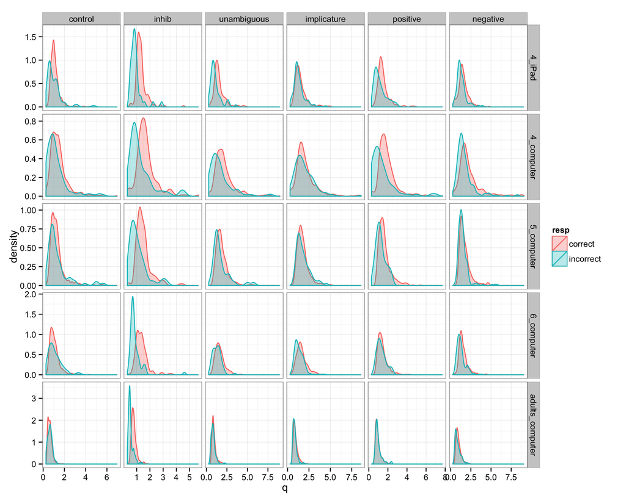

```r
#Make a bunch of plots:
ggplot(d, aes(x=q)) +
  geom_density(aes(group=resp, colour=resp, fill=resp), alpha=0.3) +
  facet_grid(agegroup_modality ~ trial.type, scales = "free") +
  scale_fill_hue(labels = c("correct", "incorrect")) +
  scale_color_hue(labels = c("correct", "incorrect")) +
  theme_bw()
```

## Estimating parameters

Calculate parameters for each condition separately, within each subject. Then aggregate across subjects to get means & confidence intervals on the parameters, and plot the parameters across each game & condition.

```r
sub.pars <- data.frame(Separation = numeric(),
                       Non.Decision = numeric(),
                       Bias = numeric(),
                       Drift = numeric(),
                       Trial.Type = character(),
                       SubID = character(),
                       Age = character(),
                       Modality = character())
sub.pars$Trial.Type <- as.character(sub.pars$Trial.Type)
sub.pars$SubID <- as.character(sub.pars$SubID)
sub.pars$Age <- as.character(sub.pars$Age)
sub.pars$Modality <- as.character(sub.pars$Modality)

temp.pars <- sub.pars

#because RWiener is finicky:
d$resp <- as.character(d$resp)
```

```r
trialtypes <- c("control", "inhib", "unambiguous", "implicature", "positive", "negative")
subs <- unique(d$subid)

for (j in 1:length(subs)) {
  sid <- as.character(subs[j])
  for (i in 1:length(trialtypes)) {
    ttype <- as.character(trialtypes[i])
    dat <- as.data.frame(subset(d, trial.type == ttype & subid == sid))
    opt <- optim(c(1, .1, .1, 1), wiener_deviance,
                 dat=select(dat, c(q, resp)), method="Nelder-Mead")
    pars <- c(opt$par, ttype, sid, as.character(dat$agegroup[1]), as.character(dat$modality[1]))
    temp.pars[i,] <- pars
  }
  sub.pars <- rbind(temp.pars, sub.pars)
  temp.pars <- temp.pars[0, ]
}
```

### Parameter plot 1 (terrible):

First plot the difference between parameters between conditions in different games:

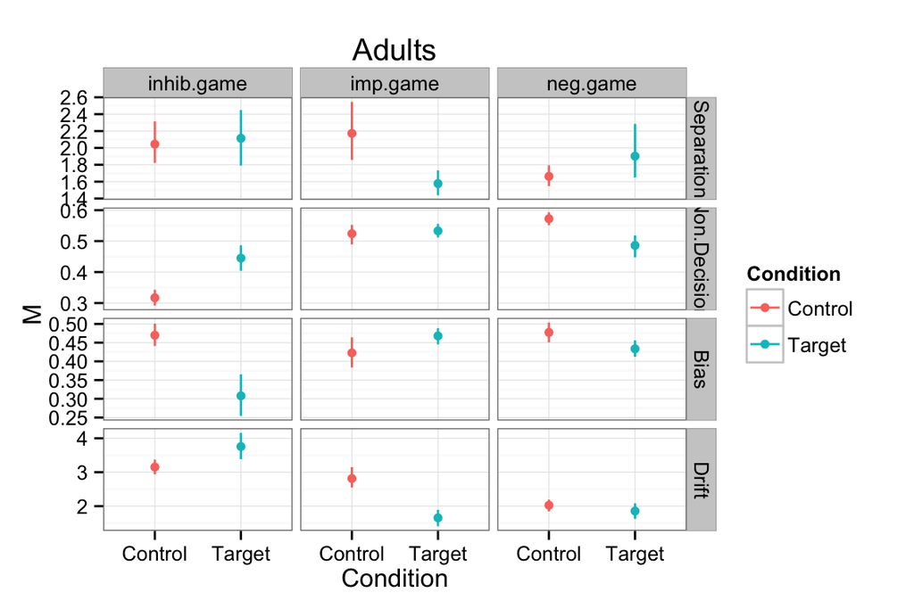

```r
sub.pars <- sub.pars %>%
  mutate(Condition = ifelse(Trial.Type == "control" | Trial.Type == "positive" | Trial.Type == "unambiguous", "Control", "Target"),
         Game = ifelse(Trial.Type == "control" | Trial.Type == "inhib", "inhib.game", ifelse(Trial.Type == "positive" | Trial.Type == "negative", "neg.game", "imp.game")))

sub.pars$Separation <- as.numeric(sub.pars$Separation)
sub.pars$Non.Decision <- as.numeric(sub.pars$Non.Decision)
sub.pars$Bias <- as.numeric(sub.pars$Bias)
sub.pars$Drift <- as.numeric(sub.pars$Drift)

sub.pars.ms <- sub.pars %>%
  gather(Param, Value, Separation:Drift) %>%
  group_by(Age, Modality, Condition, Game, Param) %>%
  summarise(M = mean(Value),
            cih = ci.high(Value),
            cil = ci.low(Value))
sub.pars.ms$Game <- factor(sub.pars.ms$Game, levels = c("inhib.game", "imp.game", "neg.game"))
sub.pars.ms$AgeModality <- paste(sub.pars.ms$Age, sub.pars.ms$Modality, sep = "_")

qplot(data = subset(sub.pars.ms, Age == "adults"), x = Condition, color = Condition,
      y = M, ymax=cih, ymin=cil,
      geom = "pointrange", position = position_dodge(.1)) +
  facet_grid(Param ~ Game, scales = "free") +
  ggtitle("Adults") +
  theme_bw()
```

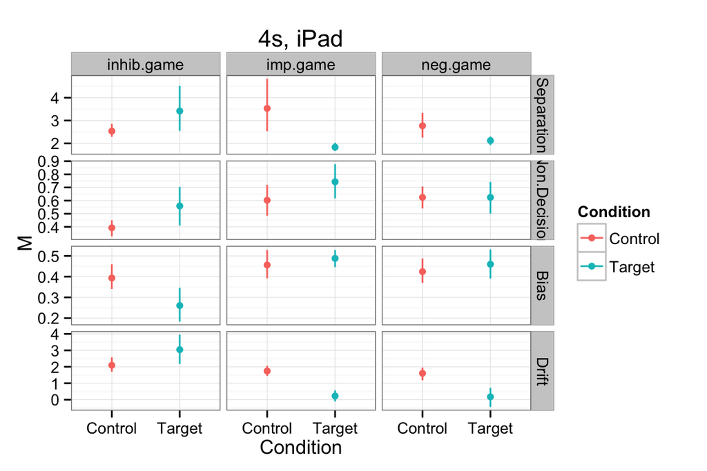

```r
qplot(data = subset(sub.pars.ms, Age == "4" & Modality == "iPad"), x = Condition, color = Condition,
      y = M, ymax=cih, ymin=cil,
      geom = "pointrange", position = position_dodge(.1)) +
  facet_grid(Param ~ Game, scales = "free") +
  ggtitle("4s, iPad") +
  theme_bw()
```

[figure not shown]

```r
qplot(data = subset(sub.pars.ms, Age == "4" & Modality == "computer"), x = Condition, color = Condition,
      y = M, ymax=cih, ymin=cil,
      geom = "pointrange", position = position_dodge(.1)) +
  facet_grid(Param ~ Game, scales = "free") +
  ggtitle("4s, iPad") +
  theme_bw()
```

[figure not shown]

```r
qplot(data = subset(sub.pars.ms, Age == "5" & Modality == "computer"), x = Condition, color = Condition,
      y = M, ymax=cih, ymin=cil,
      geom = "pointrange", position = position_dodge(.1)) +
  facet_grid(Param ~ Game, scales = "free") +
  ggtitle("5s, iPad") +
  theme_bw()
```

[figure not shown]

```r
qplot(data = subset(sub.pars.ms, Age == "6" & Modality == "computer"), x = Condition, color = Condition,
      y = M, ymax=cih, ymin=cil,
      geom = "pointrange", position = position_dodge(.1)) +
  facet_grid(Param ~ Game, scales = "free") +
  ggtitle("6s, iPad") +
  theme_bw()
```

It looks like performance on these games is driven by different processes in both adults and children:

For adults computer vs. 4s iPad: - The difference between conditions in the inhibition game is driven largely by the stronger bias towards the incorrect (lower) boundary in the target condition.  
- In the implicatures game, the control condition has a higher separation boundary (e.g. more conservative decision criteria?) but also a higher drift rate; note that this could explain the similar RTs in these two conditions.  
- In the negation game, it looks like the two conditions (positive v. negative sentences) are really similar, except for kids, where the drift rate is much lower in the target condition (i.e. negative sentences). Note that this looks like the most striking difference between adults and kids, except for main effects (e.g. kids have higher separation boundaries, longer non-decision times, and slower drift rates, consistent with past work)

### Parameter Plot 2 (less terrible?):

These plots are a nightmare.

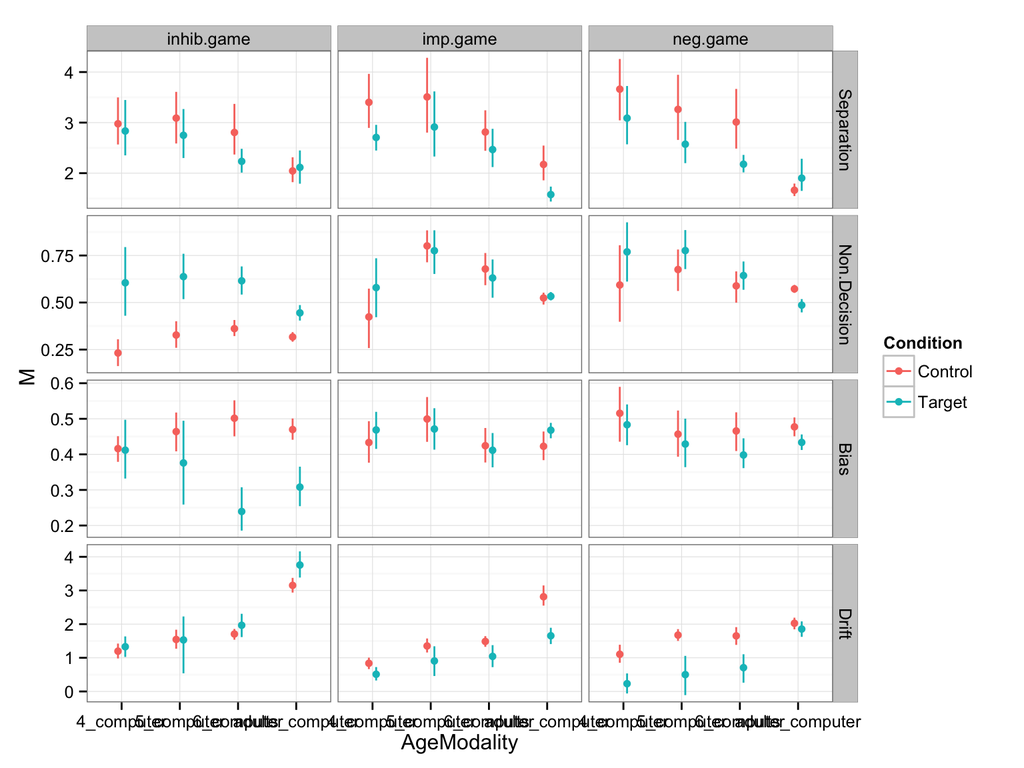

```r
qplot(data = filter(sub.pars.ms, Modality == "computer"), x = AgeModality, color = Condition,
      y = M, ymax=cih, ymin=cil,
      geom = "pointrange", position = position_dodge(.25)) +
  facet_grid(Param ~ Game, scales = "free") +
  theme_bw()
```

### Plot diffusion process:

We can also take these parameters and visualize the actual diffusion process for each game/condition/age group:

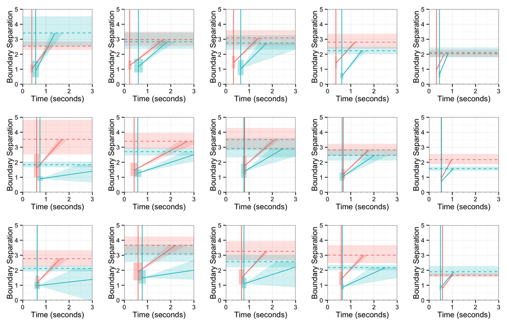

```r
#Visualize diffusion process for each game & condition
games <- c("inhib.game", "imp.game", "neg.game")
agemodality <- unique(sub.pars.ms$AgeModality)
p <- list()

x <- 3
y <- 5

for (a in 1:length(agemodality)) {
  for (g in 1:length(games)) {
    params <- sub.pars.ms %>%
      subset(Game == games[g] & AgeModality == agemodality[a]) %>%
      gather(Name, Value, M:cil) %>%
      unite(Stats, Param, Name) %>%
      spread(Stats, Value)
    params$yint_M = (params$Bias_M*params$Separation_M) - (params$Drift_M*params$Non.Decision_M)
    params$yint_cih = (params$Bias_M*params$Separation_M) - (params$Drift_cih*params$Non.Decision_M)
    params$yint_cil = (params$Bias_M*params$Separation_M) - (params$Drift_cil*params$Non.Decision_M)

    drift_ribbon <- data.frame(xvals = c(params$Non.Decision_M, #non-decision time
                                         (params$Separation_M - params$yint_cih) / params$Drift_cih, #Point where high drift line hits separation boundary
                                         (params$Separation_M - params$yint_M) / params$Drift_M, #Point where drift line hits separation boundary
                                         ifelse(params$Drift_cil > 0, (params$Separation_M - params$yint_cil) / params$Drift_cil, (0 - params$yint_cil) / params$Drift_cil)), #Point where low drift line hits separation boundary or 0
                               ymin = c(params$Bias_M * params$Separation_M, #point where drift starts
                                        params$Drift_cil*((params$Separation_M - params$yint_cih) / params$Drift_cih) + params$yint_cil, #point where low drift is when high drift ends
                                        params$Drift_cil*((params$Separation_M - params$yint_M) / params$Drift_M) + params$yint_cil, #point where low drift is when drift ends
                                        ifelse(params$Drift_cil > 0, params$Separation_M, 0)), #point where low drift ends
                               ymax = c(params$Bias_M * params$Separation_M, #point where drift starts
                                        params$Separation_M, #point where drift ends
                                         params$Separation_M, #point where drift ends
                                        params$Separation_M),#point where drift ends
                               Condition = rep(params$Condition, 4))

    nd_ribbon <- data.frame(xmin = params$Non.Decision_cil,
                            xmax = params$Non.Decision_cih,
                            ymin = rep(params$Bias_cil*params$Separation_cil, 2),
                            ymax = rep(params$Bias_cih*params$Separation_cih, 2),
                            Condition = params$Condition)

    sep_ribbon <- data.frame(xmin = rep(c(0), 2),
                             xmax = rep(x, 2),
                             ymin = params$Separation_cil,
                             ymax = params$Separation_cih,
                             Condition = params$Condition)

    df <- data.frame()

    p[[g + 3*(a-1)]] <- ggplot(df) + coord_cartesian(xlim = c(0, x), ylim = c(0, y)) +
      geom_point() +  theme_bw() +
      geom_segment(data = params,
                   aes(x = Non.Decision_M,
                       xend = (Separation_M - yint_M) / Drift_M,
                       y = Bias_M * Separation_M, yend = Separation_M,
                       color = Condition)) +
      geom_rect(data = nd_ribbon,
                aes(xmin = xmin,
                    xmax = xmax,
                    ymin = ymin,
                    ymax = ymax,
                    fill = Condition),
                alpha=0.2) +
      geom_ribbon(data = drift_ribbon,
                  aes(x = xvals,
                      ymin = ymin,
                      ymax = ymax,
                      fill = Condition),
                  alpha=0.2) +
      geom_rect(data = sep_ribbon,
                aes(xmin = xmin,
                    xmax = xmax,
                    ymin = ymin,
                    ymax = ymax,
                    fill = Condition),
                alpha=0.2) +
      geom_hline(data = params,
                 aes(yintercept = Separation_M, color = Condition),
                 linetype = "dashed") +
      geom_hline(yintercept = 0, linetype = "dashed") +
      geom_vline(data = params,
                 aes(xintercept = Non.Decision_M, color = Condition)) +
      scale_fill_discrete(guide = FALSE) +
      scale_color_discrete(guide = FALSE) +
      xlab("Time (seconds)") + ylab("Boundary Separation") #+ #ggtitle(paste(agemodality[a], "\n", games[g], sep = " "))
  }
}

plotlist <- c(list(p[[4]], p[[1]], p[[7]], p[[10]], p[[13]],
                   p[[5]], p[[2]], p[[8]], p[[11]], p[[14]],
                   p[[6]], p[[3]], p[[9]], p[[12]], p[[15]]), ncol = 5, nrow = 3)
do.call(grid.arrange, plotlist)
```

Pink = control condition and green = target condition (I removed the legend to make more space)

For kids comp vs. kids iPad, it looks like there is more variability on the iPad? But in some ways kids on the iPad actually look more like adults: For example, in the inhibition game, kids don’t start to show the inhibition bias until age 6 on the computer, but they show it at 4 on the iPad (this is a little hard to see in these graphs, because of the difference in boundary separation, but is clearer in the previous set of graphs that just compares param values across different agegroups/modalities). And in the implicatures game, kids show the difference in boundary separation on the iPad, but not really on the computer, though it looks like this might be a power issue for the computer data set (?). In other ways, kids on the computer look more like adults on the computer, especially in overall parameter values.

On the negation game, interestingly, there isn’t a ton of developmental change; even 6 year olds are still really struggling on this game, whereas adults have no problem at all. I think this is really interesting, though isn’t clear what the kids are missing.

The problem with this plot is that, when they are all plotted on the same axes (to show the differences between games and agegroups more clearly), the adult plots are hard to read. I’m zooming in here:

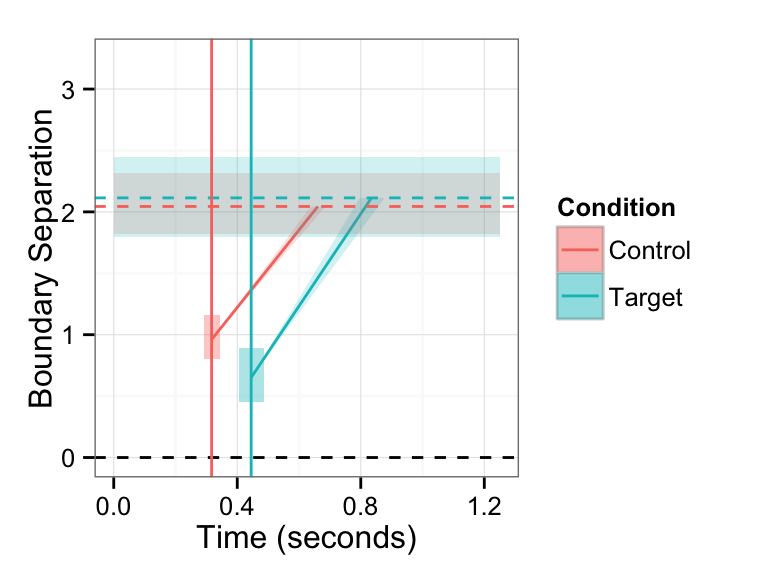

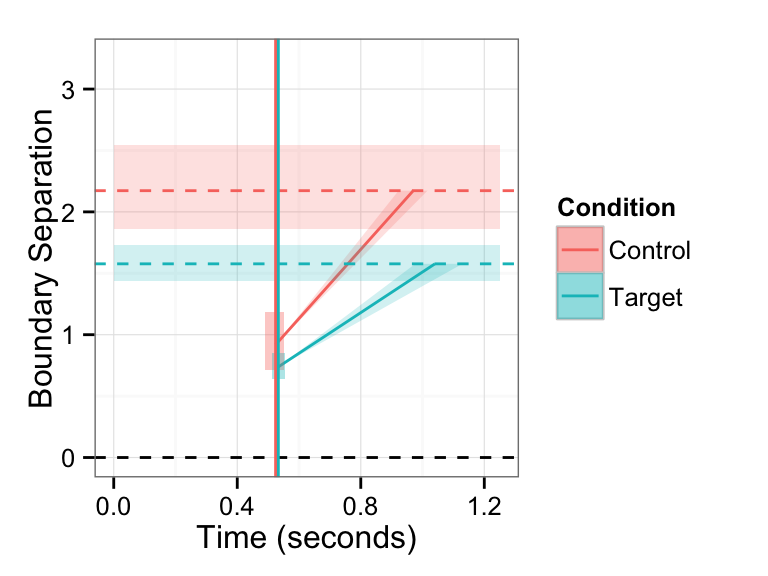

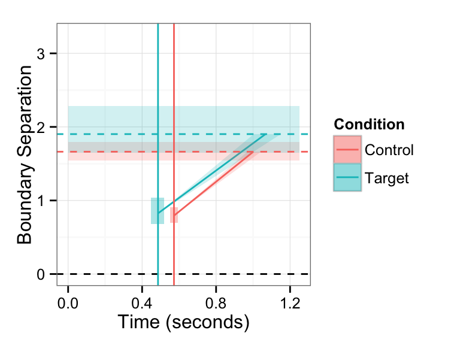

```r
x <- 1.25
y <- 3.25

p <- list()

for (g in 1:length(games)) {
  params <- sub.pars.ms %>%
    subset(Game == games[g] & Age == "adults") %>%
    gather(Name, Value, M:cil) %>%
    unite(Stats, Param, Name) %>%
    spread(Stats, Value)
  params$yint_M = (params$Bias_M*params$Separation_M) - (params$Drift_M*params$Non.Decision_M)
  params$yint_cih = (params$Bias_M*params$Separation_M) - (params$Drift_cih*params$Non.Decision_M)
  params$yint_cil = (params$Bias_M*params$Separation_M) - (params$Drift_cil*params$Non.Decision_M)

  drift_ribbon <- data.frame(xvals = c(params$Non.Decision_M, #non-decision time
                                       (params$Separation_M - params$yint_cih) / params$Drift_cih, #Point where high drift line hits separation boundary
                                       (params$Separation_M - params$yint_cil) / params$Drift_cil), #Point where low drift line hits separation boundary
                             ymin = c(params$Bias_M * params$Separation_M, #point where drift starts
                                      params$Drift_cil*((params$Separation_M - params$yint_cih) / params$Drift_cih) + params$yint_cil, #point where low drift is when high drift ends
                                      params$Separation_M), #point where low drift ends
                             ymax = c(params$Bias_M * params$Separation_M, #point where drift starts
                                      params$Separation_M, #point where drift ends
                                      params$Separation_M),#point where drift ends
                             Condition = rep(params$Condition, 3))

  nd_ribbon <- data.frame(xmin = params$Non.Decision_cil,
                          xmax = params$Non.Decision_cih,
                          ymin = rep(params$Bias_cil*params$Separation_cil, 2),
                          ymax = rep(params$Bias_cih*params$Separation_cih, 2),
                          Condition = params$Condition)

  sep_ribbon <- data.frame(xmin = rep(c(0), 2),
                           xmax = rep(x, 2),
                           ymin = params$Separation_cil,
                           ymax = params$Separation_cih,
                           Condition = params$Condition)

  df <- data.frame()

  p[[g]] <- ggplot(df) + ylim(c(0, y)) + xlim(c(0, x)) +
    geom_point() +  theme_bw() +
    geom_segment(data = params,
                 aes(x = Non.Decision_M,
                     xend = (Separation_M - yint_M) / Drift_M,
                     y = Bias_M * Separation_M, yend = Separation_M,
                     color = Condition)) +
    geom_rect(data = nd_ribbon,
              aes(xmin = xmin,
                  xmax = xmax,
                  ymin = ymin,
                  ymax = ymax,
                  fill = Condition),
              alpha=0.2) +
    geom_ribbon(data = drift_ribbon,
                aes(x = xvals,
                    ymin = ymin,
                    ymax = ymax,
                    fill = Condition),
                alpha=0.2) +
    geom_rect(data = sep_ribbon,
              aes(xmin = xmin,
                  xmax = xmax,
                  ymin = ymin,
                  ymax = ymax,
                  fill = Condition),
              alpha=0.2) +
    geom_hline(data = params,
               aes(yintercept = Separation_M, color = Condition),
               linetype = "dashed") +
    geom_hline(yintercept = 0, linetype = "dashed") +
    geom_vline(data = params,
               aes(xintercept = Non.Decision_M, color = Condition)) +
    #theme(legend.position=c(.9, .8)) +
    xlab("Time (seconds)") + ylab("Boundary Separation") #+ #ggtitle(paste("adults", games[g], sep = " "))
}


print(p)
```

# Statistics

## Adult data t-tests

```r
sub.pars$Age <- factor(sub.pars$Age, levels = c("adults", "4", "5", "6"))
sub.pars$Condition <- factor(sub.pars$Condition)

#adult t tests
inhib.bias <- sub.pars %>%
  filter(Age == "adults", Game == "inhib.game") %>%
  select(Bias, SubID, Condition) %>%
  spread(Condition, Bias)

t.test(inhib.bias$Control, inhib.bias$Target, paired = T)
```

```
##
##  Paired t-test
##
## data:  inhib.bias$Control and inhib.bias$Target
## t = 4.7545, df = 47, p-value = 1.919e-05
## alternative hypothesis: true difference in means is not equal to 0
## 95 percent confidence interval:
##  0.09336884 0.23033606
## sample estimates:
## mean of the differences
##               0.1618524
```

```r
imp.sep <- sub.pars %>%
  filter(Age == "adults", Game == "imp.game") %>%
  select(Separation, SubID, Condition) %>%
  spread(Condition, Separation)

t.test(imp.sep$Control, imp.sep$Target, paired = T)
```

```
##
##  Paired t-test
##
## data:  imp.sep$Control and imp.sep$Target
## t = 3.6704, df = 47, p-value = 0.0006174
## alternative hypothesis: true difference in means is not equal to 0
## 95 percent confidence interval:
##  0.2691738 0.9221259
## sample estimates:
## mean of the differences
##               0.5956498
```

```r
imp.drift <- sub.pars %>%
  filter(Age == "adults", Game == "imp.game") %>%
  select(Drift, SubID, Condition) %>%
  spread(Condition, Drift)

t.test(imp.drift$Control, imp.drift$Target, paired = T)
```

```
##
##  Paired t-test
##
## data:  imp.drift$Control and imp.drift$Target
## t = 6.6444, df = 47, p-value = 2.833e-08
## alternative hypothesis: true difference in means is not equal to 0
## 95 percent confidence interval:
##  0.8081183 1.5099652
## sample estimates:
## mean of the differences
##                1.159042
```

```r
neg.drift <- sub.pars %>%
  filter(Age == "adults", Game == "neg.game") %>%
  select(Drift, SubID, Condition) %>%
  spread(Condition, Drift)

t.test(neg.drift$Control, neg.drift$Target, paired = T)
```

```
##
##  Paired t-test
##
## data:  neg.drift$Control and neg.drift$Target
## t = 1.2261, df = 47, p-value = 0.2263
## alternative hypothesis: true difference in means is not equal to 0
## 95 percent confidence interval:
##  -0.1099597  0.4531745
## sample estimates:
## mean of the differences
##               0.1716074
```

```r
#Note: Non-decision is sig for negation game (and inhib too, I suspect), but I'm not really sure what to say about this, so I didn't discuss it in the paper.  Maybe we should though?
neg.nd <- sub.pars %>%
  filter(Age == "adults", Game == "neg.game") %>%
  select(Non.Decision, SubID, Condition) %>%
  spread(Condition, Non.Decision)

t.test(neg.nd$Control, neg.nd$Target, paired = T)
```

```
##
##  Paired t-test
##
## data:  neg.nd$Control and neg.nd$Target
## t = 5.2051, df = 47, p-value = 4.191e-06
## alternative hypothesis: true difference in means is not equal to 0
## 95 percent confidence interval:
##  0.05292682 0.11961247
## sample estimates:
## mean of the differences
##              0.08626965
```

## Developmental Change across games

```r
##Inhibition game
inhib <- filter(sub.pars, Modality == "computer" & Game == "inhib.game")

inhib.sep <- lm(Separation ~ Age * Condition, data = inhib)
summary(inhib.sep)
```

```
##
## Call:
## lm(formula = Separation ~ Age * Condition, data = inhib)
##
## Residuals:
##     Min      1Q  Median      3Q     Max
## -1.6091 -0.6647 -0.2995  0.1879  5.4115
##
## Coefficients:
##                      Estimate Std. Error t value Pr(>|t|)
## (Intercept)           2.04413    0.16182  12.632  < 2e-16 ***
## Age4                  0.93336    0.28865   3.234 0.001410 **
## Age5                  1.04502    0.30387   3.439 0.000698 ***
## Age6                  0.76134    0.27652   2.753 0.006392 **
## ConditionTarget       0.06979    0.22885   0.305 0.760687
## Age4:ConditionTarget -0.21287    0.40821  -0.521 0.602553
## Age5:ConditionTarget -0.40972    0.42974  -0.953 0.341427
## Age6:ConditionTarget -0.64144    0.39105  -1.640 0.102375
## ---
## Signif. codes:  0 '***' 0.001 '**' 0.01 '*' 0.05 '.' 0.1 ' ' 1
##
## Residual standard error: 1.121 on 220 degrees of freedom
## Multiple R-squared:  0.1162, Adjusted R-squared:  0.08805
## F-statistic: 4.131 on 7 and 220 DF,  p-value: 0.0002739
```

```r
inhib.nd <- lm(Non.Decision ~ Age * Condition, data = inhib)
summary(inhib.nd)
```

```
##
## Call:
## lm(formula = Non.Decision ~ Age * Condition, data = inhib)
##
## Residuals:
##      Min       1Q   Median       3Q      Max
## -0.61717 -0.08675 -0.02820  0.10499  0.77778
##
## Coefficients:
##                      Estimate Std. Error t value Pr(>|t|)
## (Intercept)           0.31693    0.03014  10.515  < 2e-16 ***
## Age4                 -0.08504    0.05377  -1.582  0.11517
## Age5                  0.01039    0.05660   0.184  0.85455
## Age6                  0.04432    0.05151   0.860  0.39046
## ConditionTarget       0.12808    0.04263   3.005  0.00297 **
## Age4:ConditionTarget  0.24498    0.07604   3.222  0.00147 **
## Age5:ConditionTarget  0.18229    0.08005   2.277  0.02373 *
## Age6:ConditionTarget  0.12606    0.07284   1.731  0.08492 .
## ---
## Signif. codes:  0 '***' 0.001 '**' 0.01 '*' 0.05 '.' 0.1 ' ' 1
##
## Residual standard error: 0.2088 on 220 degrees of freedom
## Multiple R-squared:  0.3024, Adjusted R-squared:  0.2802
## F-statistic: 13.62 on 7 and 220 DF,  p-value: 1.325e-14
```

```r
inhib.bias <- lm(Bias ~ Age * Condition, data = inhib)
summary(inhib.bias)
```

```
##
## Call:
## lm(formula = Bias ~ Age * Condition, data = inhib)
##
## Residuals:
##      Min       1Q   Median       3Q      Max
## -0.31902 -0.11397 -0.02841  0.08424  0.62220
##
## Coefficients:
##                       Estimate Std. Error t value Pr(>|t|)
## (Intercept)           0.469761   0.024343  19.298  < 2e-16 ***
## Age4                 -0.053650   0.043422  -1.236   0.2179
## Age5                 -0.005701   0.045712  -0.125   0.9009
## Age6                  0.031814   0.041597   0.765   0.4452
## ConditionTarget      -0.161852   0.034426  -4.701 4.56e-06 ***
## Age4:ConditionTarget  0.157516   0.061408   2.565   0.0110 *
## Age5:ConditionTarget  0.073707   0.064647   1.140   0.2555
## Age6:ConditionTarget -0.100305   0.058827  -1.705   0.0896 .
## ---
## Signif. codes:  0 '***' 0.001 '**' 0.01 '*' 0.05 '.' 0.1 ' ' 1
##
## Residual standard error: 0.1687 on 220 degrees of freedom
## Multiple R-squared:  0.2072, Adjusted R-squared:  0.1819
## F-statistic: 8.212 on 7 and 220 DF,  p-value: 6.889e-09
```

```r
inhib.drift <- lm(Drift ~ Age * Condition, data = inhib)
summary(inhib.drift)
```

```
##
## Call:
## lm(formula = Drift ~ Age * Condition, data = inhib)
##
## Residuals:
##     Min      1Q  Median      3Q     Max
## -7.0820 -0.4617 -0.0829  0.5374  3.5271
##
## Coefficients:
##                      Estimate Std. Error t value Pr(>|t|)
## (Intercept)            3.1512     0.1503  20.959  < 2e-16 ***
## Age4                  -1.9549     0.2682  -7.289 5.53e-12 ***
## Age5                  -1.6071     0.2823  -5.692 3.98e-08 ***
## Age6                  -1.4449     0.2569  -5.624 5.63e-08 ***
## ConditionTarget        0.6052     0.2126   2.846  0.00484 **
## Age4:ConditionTarget  -0.4725     0.3793  -1.246  0.21414
## Age5:ConditionTarget  -0.6185     0.3993  -1.549  0.12278
## Age6:ConditionTarget  -0.3455     0.3633  -0.951  0.34275
## ---
## Signif. codes:  0 '***' 0.001 '**' 0.01 '*' 0.05 '.' 0.1 ' ' 1
##
## Residual standard error: 1.042 on 220 degrees of freedom
## Multiple R-squared:  0.4763, Adjusted R-squared:  0.4596
## F-statistic: 28.58 on 7 and 220 DF,  p-value: < 2.2e-16
```

```r
##Implicature game
imp <- filter(sub.pars, Modality == "computer" & Game == "imp.game")

imp.sep <- lm(Separation ~ Age * Condition, data = imp)
summary(imp.sep)
```

```
##
## Call:
## lm(formula = Separation ~ Age * Condition, data = imp)
##
## Residuals:
##     Min      1Q  Median      3Q     Max
## -1.7071 -0.6651 -0.3204  0.2666  5.8551
##
## Coefficients:
##                        Estimate Std. Error t value Pr(>|t|)
## (Intercept)           2.1726275  0.1629370  13.334  < 2e-16 ***
## Age4                  1.2284282  0.2906413   4.227 3.48e-05 ***
## Age5                  1.3356505  0.3059710   4.365 1.95e-05 ***
## Age6                  0.6411209  0.2784269   2.303   0.0222 *
## ConditionTarget      -0.5956498  0.2304277  -2.585   0.0104 *
## Age4:ConditionTarget -0.0991596  0.4110289  -0.241   0.8096
## Age5:ConditionTarget  0.0007585  0.4327084   0.002   0.9986
## Age6:ConditionTarget  0.2485562  0.3937550   0.631   0.5285
## ---
## Signif. codes:  0 '***' 0.001 '**' 0.01 '*' 0.05 '.' 0.1 ' ' 1
##
## Residual standard error: 1.129 on 220 degrees of freedom
## Multiple R-squared:  0.2428, Adjusted R-squared:  0.2187
## F-statistic: 10.08 on 7 and 220 DF,  p-value: 6.433e-11
```

```r
imp.nd <- lm(Non.Decision ~ Age * Condition, data = imp)
summary(imp.nd)
```

```
##
## Call:
## lm(formula = Non.Decision ~ Age * Condition, data = imp)
##
## Residuals:
##      Min       1Q   Median       3Q      Max
## -0.77551 -0.08043  0.00908  0.09817  0.85440
##
## Coefficients:
##                       Estimate Std. Error t value Pr(>|t|)
## (Intercept)           0.524134   0.033879  15.471  < 2e-16 ***
## Age4                 -0.100444   0.060433  -1.662  0.09792 .
## Age5                  0.276844   0.063620   4.352 2.07e-05 ***
## Age6                  0.154127   0.057893   2.662  0.00833 **
## ConditionTarget       0.008892   0.047912   0.186  0.85293
## Age4:ConditionTarget  0.146717   0.085465   1.717  0.08744 .
## Age5:ConditionTarget -0.034365   0.089972  -0.382  0.70287
## Age6:ConditionTarget -0.056512   0.081873  -0.690  0.49077
## ---
## Signif. codes:  0 '***' 0.001 '**' 0.01 '*' 0.05 '.' 0.1 ' ' 1
##
## Residual standard error: 0.2347 on 220 degrees of freedom
## Multiple R-squared:  0.1825, Adjusted R-squared:  0.1565
## F-statistic: 7.018 on 7 and 220 DF,  p-value: 1.472e-07
```

```r
imp.bias <- lm(Bias ~ Age * Condition, data = imp)
summary(imp.bias)
```

```
##
## Call:
## lm(formula = Bias ~ Age * Condition, data = imp)
##
## Residuals:
##      Min       1Q   Median       3Q      Max
## -0.33283 -0.06891 -0.00699  0.07007  0.43977
##
## Coefficients:
##                       Estimate Std. Error t value Pr(>|t|)
## (Intercept)           0.422696   0.018206  23.217   <2e-16 ***
## Age4                  0.010593   0.032476   0.326   0.7446
## Age5                  0.076732   0.034188   2.244   0.0258 *
## Age6                  0.001631   0.031111   0.052   0.9582
## ConditionTarget       0.045310   0.025747   1.760   0.0798 .
## Age4:ConditionTarget -0.009916   0.045927  -0.216   0.8293
## Age5:ConditionTarget -0.073434   0.048350  -1.519   0.1302
## Age6:ConditionTarget -0.058149   0.043997  -1.322   0.1877
## ---
## Signif. codes:  0 '***' 0.001 '**' 0.01 '*' 0.05 '.' 0.1 ' ' 1
##
## Residual standard error: 0.1261 on 220 degrees of freedom
## Multiple R-squared:  0.0468, Adjusted R-squared:  0.01647
## F-statistic: 1.543 on 7 and 220 DF,  p-value: 0.154
```

```r
imp.drift <- lm(Drift ~ Age * Condition, data = imp)
summary(imp.drift)
```

```
##
## Call:
## lm(formula = Drift ~ Age * Condition, data = imp)
##
## Residuals:
##     Min      1Q  Median      3Q     Max
## -2.4440 -0.4415 -0.0413  0.3840  5.4571
##
## Coefficients:
##                      Estimate Std. Error t value Pr(>|t|)
## (Intercept)            2.8135     0.1160  24.251  < 2e-16 ***
## Age4                  -1.9772     0.2069  -9.554  < 2e-16 ***
## Age5                  -1.4623     0.2179  -6.712 1.60e-10 ***
## Age6                  -1.3278     0.1982  -6.698 1.74e-10 ***
## ConditionTarget       -1.1590     0.1641  -7.064 2.10e-11 ***
## Age4:ConditionTarget   0.8331     0.2927   2.847  0.00484 **
## Age5:ConditionTarget   0.7143     0.3081   2.319  0.02134 *
## Age6:ConditionTarget   0.7148     0.2804   2.550  0.01146 *
## ---
## Signif. codes:  0 '***' 0.001 '**' 0.01 '*' 0.05 '.' 0.1 ' ' 1
##
## Residual standard error: 0.8038 on 220 degrees of freedom
## Multiple R-squared:  0.4724, Adjusted R-squared:  0.4557
## F-statistic: 28.15 on 7 and 220 DF,  p-value: < 2.2e-16
```

```r
##Negation game
neg <- filter(sub.pars, Modality == "computer" & Game == "neg.game")

neg.sep <- lm(Separation ~ Age * Condition, data = neg)
summary(neg.sep)
```

```
##
## Call:
## lm(formula = Separation ~ Age * Condition, data = neg)
##
## Residuals:
##     Min      1Q  Median      3Q     Max
## -1.6936 -0.5165 -0.2441  0.1221  7.8007
##
## Coefficients:
##                      Estimate Std. Error t value Pr(>|t|)
## (Intercept)            1.6627     0.1648  10.086  < 2e-16 ***
## Age4                   1.9989     0.2941   6.798 9.85e-11 ***
## Age5                   1.5985     0.3096   5.164 5.41e-07 ***
## Age6                   1.3484     0.2817   4.787 3.11e-06 ***
## ConditionTarget        0.2395     0.2331   1.027   0.3055
## Age4:ConditionTarget  -0.8126     0.4159  -1.954   0.0520 .
## Age5:ConditionTarget  -0.9279     0.4378  -2.120   0.0352 *
## Age6:ConditionTarget  -1.0734     0.3984  -2.694   0.0076 **
## ---
## Signif. codes:  0 '***' 0.001 '**' 0.01 '*' 0.05 '.' 0.1 ' ' 1
##
## Residual standard error: 1.142 on 220 degrees of freedom
## Multiple R-squared:  0.2733, Adjusted R-squared:  0.2502
## F-statistic: 11.82 on 7 and 220 DF,  p-value: 9.224e-13
```

```r
neg.nd <- lm(Non.Decision ~ Age * Condition , data = neg)
summary(neg.nd)
```

```
##
## Call:
## lm(formula = Non.Decision ~ Age * Condition, data = neg)
##
## Residuals:
##      Min       1Q   Median       3Q      Max
## -0.76935 -0.08663  0.00444  0.10187  0.99783
##
## Coefficients:
##                      Estimate Std. Error t value Pr(>|t|)
## (Intercept)           0.57230    0.03548  16.130  < 2e-16 ***
## Age4                  0.02092    0.06329   0.331  0.74131
## Age5                  0.10307    0.06663   1.547  0.12328
## Age6                  0.01638    0.06063   0.270  0.78722
## ConditionTarget      -0.08627    0.05018  -1.719  0.08696 .
## Age4:ConditionTarget  0.26241    0.08950   2.932  0.00373 **
## Age5:ConditionTarget  0.18702    0.09422   1.985  0.04841 *
## Age6:ConditionTarget  0.14102    0.08574   1.645  0.10144
## ---
## Signif. codes:  0 '***' 0.001 '**' 0.01 '*' 0.05 '.' 0.1 ' ' 1
##
## Residual standard error: 0.2458 on 220 degrees of freedom
## Multiple R-squared:  0.1317, Adjusted R-squared:  0.104
## F-statistic: 4.765 on 7 and 220 DF,  p-value: 5.231e-05
```

```r
neg.bias <- lm(Bias ~ Age * Condition, data = neg)
summary(neg.bias)
```

```
##
## Call:
## lm(formula = Bias ~ Age * Condition, data = neg)
##
## Residuals:
##      Min       1Q   Median       3Q      Max
## -0.44662 -0.07371 -0.01517  0.06940  0.31166
##
## Coefficients:
##                      Estimate Std. Error t value Pr(>|t|)
## (Intercept)           0.47733    0.01820  26.224   <2e-16 ***
## Age4                  0.03815    0.03247   1.175    0.241
## Age5                 -0.02058    0.03418  -0.602    0.548
## Age6                 -0.01154    0.03110  -0.371    0.711
## ConditionTarget      -0.04370    0.02574  -1.698    0.091 .
## Age4:ConditionTarget  0.01156    0.04592   0.252    0.801
## Age5:ConditionTarget  0.01594    0.04834   0.330    0.742
## Age6:ConditionTarget -0.02386    0.04399  -0.542    0.588
## ---
## Signif. codes:  0 '***' 0.001 '**' 0.01 '*' 0.05 '.' 0.1 ' ' 1
##
## Residual standard error: 0.1261 on 220 degrees of freedom
## Multiple R-squared:  0.06412,    Adjusted R-squared:  0.03434
## F-statistic: 2.153 on 7 and 220 DF,  p-value: 0.03943
```

```r
neg.drift <- lm(Drift ~ Age * Condition, data = neg)
summary(neg.drift)
```

```
##
## Call:
## lm(formula = Drift ~ Age * Condition, data = neg)
##
## Residuals:
##     Min      1Q  Median      3Q     Max
## -3.6798 -0.3773  0.0499  0.4634  2.4919
##
## Coefficients:
##                      Estimate Std. Error t value Pr(>|t|)
## (Intercept)            2.0260     0.1201  16.866  < 2e-16 ***
## Age4                  -0.9214     0.2143  -4.300 2.57e-05 ***
## Age5                  -0.3517     0.2256  -1.559  0.12046
## Age6                  -0.3745     0.2053  -1.825  0.06942 .
## ConditionTarget       -0.1716     0.1699  -1.010  0.31353
## Age4:ConditionTarget  -0.7022     0.3030  -2.317  0.02140 *
## Age5:ConditionTarget  -1.0025     0.3190  -3.142  0.00191 **
## Age6:ConditionTarget  -0.7726     0.2903  -2.661  0.00835 **
## ---
## Signif. codes:  0 '***' 0.001 '**' 0.01 '*' 0.05 '.' 0.1 ' ' 1
##
## Residual standard error: 0.8323 on 220 degrees of freedom
## Multiple R-squared:  0.3741, Adjusted R-squared:  0.3541
## F-statistic: 18.78 on 7 and 220 DF,  p-value: < 2.2e-16
```

## General Developmental Change

```r
#Look at changes in paramaters in general across age:
sep.model <- lm(Separation ~ Age, data = sub.pars)
summary(sep.model)
```

```
##
## Call:
## lm(formula = Separation ~ Age, data = sub.pars)
##
## Residuals:
##     Min      1Q  Median      3Q     Max
## -1.8755 -0.6611 -0.3559  0.1488  7.8281
##
## Coefficients:
##             Estimate Std. Error t value Pr(>|t|)
## (Intercept)  1.91208    0.07282  26.259  < 2e-16 ***
## Age4         1.00972    0.10728   9.412  < 2e-16 ***
## Age5         1.10359    0.13674   8.071 2.58e-15 ***
## Age6         0.67257    0.12443   5.405 8.56e-08 ***
## ---
## Signif. codes:  0 '***' 0.001 '**' 0.01 '*' 0.05 '.' 0.1 ' ' 1
##
## Residual standard error: 1.236 on 794 degrees of freedom
## Multiple R-squared:  0.1259, Adjusted R-squared:  0.1226
## F-statistic: 38.13 on 3 and 794 DF,  p-value: < 2.2e-16
```

```r
nd.model <- lm(Non.Decision ~ Age, data = sub.pars)
summary(nd.model)
```

```
##
## Call:
## lm(formula = Non.Decision ~ Age, data = sub.pars)
##
## Residuals:
##      Min       1Q   Median       3Q      Max
## -0.66550 -0.16011  0.01436  0.14605  1.03068
##
## Coefficients:
##             Estimate Std. Error t value Pr(>|t|)
## (Intercept)  0.47957    0.01542  31.092  < 2e-16 ***
## Age4         0.08080    0.02272   3.556 0.000399 ***
## Age5         0.18593    0.02896   6.419 2.36e-10 ***
## Age6         0.10671    0.02636   4.049 5.66e-05 ***
## ---
## Signif. codes:  0 '***' 0.001 '**' 0.01 '*' 0.05 '.' 0.1 ' ' 1
##
## Residual standard error: 0.2618 on 794 degrees of freedom
## Multiple R-squared:  0.0551, Adjusted R-squared:  0.05153
## F-statistic: 15.43 on 3 and 794 DF,  p-value: 9.133e-10
```

```r
bias.model <- lm(Bias ~ Age, data = sub.pars)
summary(bias.model)
```

```
##
## Call:
## lm(formula = Bias ~ Age, data = sub.pars)
##
## Residuals:
##      Min       1Q   Median       3Q      Max
## -0.39251 -0.09227  0.00141  0.09056  0.54870
##
## Coefficients:
##              Estimate Std. Error t value Pr(>|t|)
## (Intercept)  0.429888   0.009059  47.453   <2e-16 ***
## Age4         0.005878   0.013347   0.440    0.660
## Age5         0.019519   0.017012   1.147    0.252
## Age6        -0.023084   0.015480  -1.491    0.136
## ---
## Signif. codes:  0 '***' 0.001 '**' 0.01 '*' 0.05 '.' 0.1 ' ' 1
##
## Residual standard error: 0.1537 on 794 degrees of freedom
## Multiple R-squared:  0.006975,   Adjusted R-squared:  0.003223
## F-statistic: 1.859 on 3 and 794 DF,  p-value: 0.1351
```

```r
drift.model <- lm(Drift ~ Age, data = sub.pars)
summary(drift.model)
```

```
##
## Call:
## lm(formula = Drift ~ Age, data = sub.pars)
##
## Residuals:
##     Min      1Q  Median      3Q     Max
## -6.8024 -0.6256 -0.0783  0.5657  7.4965
##
## Coefficients:
##             Estimate Std. Error t value Pr(>|t|)
## (Intercept)  2.54265    0.06841  37.167   <2e-16 ***
## Age4        -1.39147    0.10079 -13.805   <2e-16 ***
## Age5        -1.29147    0.12847 -10.053   <2e-16 ***
## Age6        -1.11626    0.11690  -9.549   <2e-16 ***
## ---
## Signif. codes:  0 '***' 0.001 '**' 0.01 '*' 0.05 '.' 0.1 ' ' 1
##
## Residual standard error: 1.161 on 794 degrees of freedom
## Multiple R-squared:  0.226,  Adjusted R-squared:  0.2231
## F-statistic: 77.28 on 3 and 794 DF,  p-value: < 2.2e-16
```

```r
#Look at continuous across age group, just children
sub.pars.cont <- filter(sub.pars, Age != "adults")
sub.pars.cont$Age <- as.numeric(as.character(sub.pars.cont$Age))

cont.sep.model <- lm(Separation ~ Age, data = sub.pars.cont)
summary(cont.sep.model)
```

```
##
## Call:
## lm(formula = Separation ~ Age, data = sub.pars.cont)
##
## Residuals:
##     Min      1Q  Median      3Q     Max
## -1.7866 -0.7785 -0.4194  0.2399  7.7816
##
## Coefficients:
##             Estimate Std. Error t value Pr(>|t|)
## (Intercept)  3.58307    0.34077  10.515   <2e-16 ***
## Age         -0.15368    0.06971  -2.204   0.0279 *
## ---
## Signif. codes:  0 '***' 0.001 '**' 0.01 '*' 0.05 '.' 0.1 ' ' 1
##
## Residual standard error: 1.355 on 508 degrees of freedom
## Multiple R-squared:  0.009475,   Adjusted R-squared:  0.007525
## F-statistic: 4.859 on 1 and 508 DF,  p-value: 0.02794
```

```r
cont.nd.model <- lm(Non.Decision ~ Age, data = sub.pars.cont)
summary(cont.nd.model)
```

```
##
## Call:
## lm(formula = Non.Decision ~ Age, data = sub.pars.cont)
##
## Residuals:
##      Min       1Q   Median       3Q      Max
## -0.61310 -0.23520  0.01887  0.20925  1.01432
##
## Coefficients:
##             Estimate Std. Error t value Pr(>|t|)
## (Intercept)  0.50399    0.07878   6.397 3.59e-10 ***
## Age          0.01819    0.01612   1.128     0.26
## ---
## Signif. codes:  0 '***' 0.001 '**' 0.01 '*' 0.05 '.' 0.1 ' ' 1
##
## Residual standard error: 0.3133 on 508 degrees of freedom
## Multiple R-squared:  0.0025, Adjusted R-squared:  0.0005366
## F-statistic: 1.273 on 1 and 508 DF,  p-value: 0.2597
```

```r
cont.bias.model <- lm(Bias ~ Age, data = sub.pars.cont)
summary(cont.bias.model)
```

```
##
## Call:
## lm(formula = Bias ~ Age, data = sub.pars.cont)
##
## Residuals:
##      Min       1Q   Median       3Q      Max
## -0.38267 -0.10158 -0.00452  0.09842  0.57024
##
## Coefficients:
##              Estimate Std. Error t value Pr(>|t|)
## (Intercept)  0.492293   0.040844  12.053   <2e-16 ***
## Age         -0.012884   0.008356  -1.542    0.124
## ---
## Signif. codes:  0 '***' 0.001 '**' 0.01 '*' 0.05 '.' 0.1 ' ' 1
##
## Residual standard error: 0.1624 on 508 degrees of freedom
## Multiple R-squared:  0.004659,   Adjusted R-squared:  0.002699
## F-statistic: 2.378 on 1 and 508 DF,  p-value: 0.1237
```

```r
cont.drift.model <- lm(Drift ~ Age, data = sub.pars.cont)
summary(cont.drift.model)
```

```
##
## Call:
## lm(formula = Drift ~ Age, data = sub.pars.cont)
##
## Residuals:
##     Min      1Q  Median      3Q     Max
## -6.8312 -0.5176 -0.0399  0.5445  7.5032
##
## Coefficients:
##             Estimate Std. Error t value Pr(>|t|)
## (Intercept)  0.60262    0.28397   2.122   0.0343 *
## Age          0.13547    0.05809   2.332   0.0201 *
## ---
## Signif. codes:  0 '***' 0.001 '**' 0.01 '*' 0.05 '.' 0.1 ' ' 1
##
## Residual standard error: 1.129 on 508 degrees of freedom
## Multiple R-squared:  0.01059,    Adjusted R-squared:  0.008644
## F-statistic: 5.438 on 1 and 508 DF,  p-value: 0.02009
```